# Interpreting daily changes in recorded Facebook SMS-verification prices

Vendor prices and advertised-stock shares in three phone-number markets

## Background

SMS-verification services can help create accounts and are one input in the wider online manipulation economy; their advertised offers are not themselves evidence of an influence operation ([Dek et al., 2025](https://doi.org/10.1126/science.adw8154)). COTSI records vendor prices and advertised stock and reports a stock-weighted price for a platform and phone-number market. That combined indicator can move because continuing vendors’ recorded prices change, because their shares of advertised stock change, or both. Separating these sources of *recorded* movement helps interpret the indicator without assuming why the market changed.

## Research Question

For Facebook SMS verifications using UK, US and Indonesian phone numbers, between 1 August 2024 and 27 July 2025, how much of the daily movement in the recorded stock-weighted price consists of within-vendor recorded price movement and how much consists of vendor stock-share reweighting, on consecutive observed days with an unchanged set of at least two positive-stock vendors?

## Data

The data come from the COTSI replication archive, `verifications data_final.zip`, placed locally at `data/raw/` for reproduction but not distributed in this repository. Python read all 12 monthly files from August 2024 through July 2025 and retained Facebook (`fb`) records for the three selected phone-number markets through **27 July 2025**. The source has one country–platform–date row containing four vendors: SMSPVA, SMSHub, SMS-Activate and 5SIM. The prepared data have one country–platform–vendor–date row, with original quotes, recorded-USD prices, advertised stock, stock shares and validity/eligibility flags.

The period contains **360 observed dates per market**. **30 December 2024 is missing** in all three; it remains an explicit calendar gap. The first day has no previous-day comparison, and neither 30 nor 31 December forms a valid adjacent-day pair. Across the markets, **1,074** pairs have measurements on genuinely consecutive calendar days. Of these, **1,001** have an unchanged set of at least two positive-stock vendors and enter the decomposition; **73** have a changed vendor set and enter only the selection check. Country refers to the phone-number market, not the buyer’s location. Prices and stocks are recorded advertisements, not verified transactions.

## Methods

Python reads the archive in chunks, filters to the stated platform, market and date scope, and reshapes the four vendor columns into vendor-day rows. Chunking reads the entire intended archive without treating a batch as a sample or a time period. SMSPVA and SMSHub quotes were recorded in USD; SMS-Activate and 5SIM quotes were recorded in RUB and divided by the archive’s recorded exchange rate. The original quotes and currency labels remain in the processed file. Python checks keys, stock totals, positive-stock prices, shares and reconstructed weighted prices against the source. It then builds a complete daily calendar and checked previous-day fields without filling missing observations. The preparation audit recorded **53 PASS, 6 INFO and 0 FAIL** checks.

R verifies the exact processed-file fingerprint and sample counts before analysis. For each eligible pair and continuing vendor, it separates the change into two symmetric accounting terms:

- **Price component:** the vendor’s recorded USD price change multiplied by its average advertised-stock share across the two days.
- **Weight component:** the vendor’s advertised-stock-share change multiplied by its average recorded USD price across the two days.

The terms are summed across the continuing vendors. Their sum must equal the observed change in the source’s combined weighted price for **each** eligible pair. The method partitions the price–share interaction symmetrically; it does not identify causal mechanisms. Country-specific means and medians of **absolute** components describe movement size, while signed daily values show direction and cancellation. A separate check compares the absolute *combined-price* changes of stable- and changing-set valid pairs. Changing-set pairs are not decomposed because an entering or exiting vendor lacks a comparable quote on one day.

## Results

The decomposition identity passed for all **1,001** eligible pairs: **zero failures**, with a largest absolute discrepancy of **3.89 × 10⁻¹⁶ recorded USD per verification**. The table reports movements in **recorded USD per verification per eligible adjacent-day pair**.

| Phone-number market | Eligible pairs | Mean absolute price | Median absolute price | Mean absolute weight | Median absolute weight |
| --- | --- | --- | --- | --- | --- |
| UK (GB) | 325 | 0.018743 | 0.000991 | 0.003960 | 0.000638 |
| US | 326 | 0.021928 | 0.008116 | 0.004004 | 0.001080 |
| Indonesia (ID) | 350 | 0.014749 | 0.001724 | 0.002644 | 0.001195 |

The absolute price component was larger on more eligible pairs than the weight component in all three markets: **202/325 UK, 258/326 US and 196/350 Indonesia**. This pattern is clearest in the US and less pronounced in Indonesia; these are descriptive comparisons among purposively selected markets, not statistical tests. Opposite-signed components were common (**160, 153 and 210 pairs**, respectively), so reweighting sometimes partly concealed recorded price movement in the net indicator.

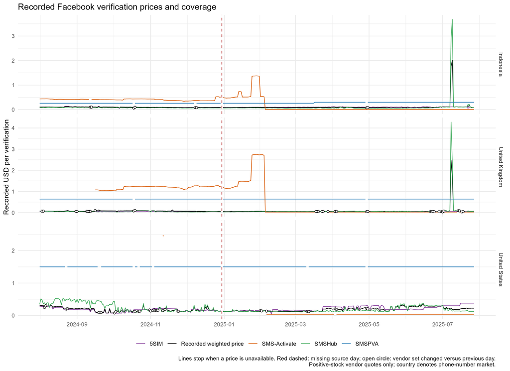

Figure 1. Recorded weighted prices and positive-stock vendor quotes by phone-number market, in recorded USD per verification. Red dashed: the missing 30 December source date; open circles: vendor-set-change pairs. Lines stop at unavailable prices. The July UK and Indonesia spikes remain visible. Vertical scales differ between country panels.

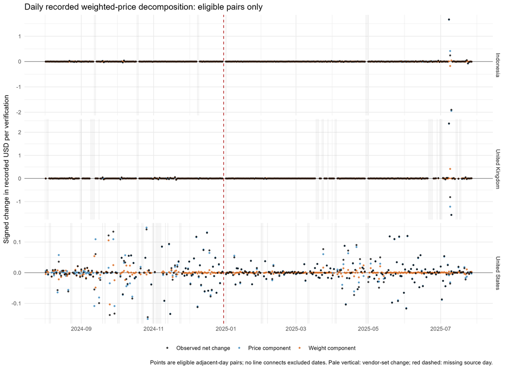

Figure 2. Signed daily decomposition for eligible stable-vendor-set pairs, in recorded USD per verification. Blue: price component; orange: stock-share weight component; black: observed net change. Red dashed: missing source date; pale vertical: changed-set pair, which is not decomposed. Points are not connected across exclusions. Vertical scales differ between country panels.

The required selection check compared the **73** changed-set pairs with stable-set pairs using absolute *observed combined-price* changes. The changing-set share of all valid pairs was larger than its share of total absolute combined-price movement in each market:

| Phone-number market | Changed-set pairs | Share of valid pairs | Share of total absolute combined-price movement |
| --- | --- | --- | --- |
| UK (GB) | 33 | 9.22% | 4.31% |
| US | 32 | 8.94% | 6.57% |
| Indonesia (ID) | 8 | 2.23% | 1.43% |

This check does not suggest that the excluded changing-set group held a disproportionate share of recorded movement over valid pairs. Changing-set median absolute movements were higher in all three markets, particularly in the UK. Their smaller share of total absolute movement therefore does **not** establish that the exclusions are inconsequential; the large *stable-set* July observations also enlarge the movement-share denominator. The decomposition remains limited to the 1,001 eligible pairs. The complete selection table also reports group means, medians and maxima.

## Limitations

Advertised stock is neither sales nor verified availability. A recorded quote is not necessarily the realised cost of a successful verification or account. Vendors may differ in service quality or product mix and may share suppliers. The archive lacks daily success rates, buyer identities and collection-status logs, so source/reporting problems—including the July recorded-price spikes—cannot be ruled out. Recorded USD price movements can also reflect the archive’s RUB conversion convention; the July SMSHub quotes discussed above were recorded in USD.

The UK, US and Indonesian phone-number markets were selected purposively and are not representative of all markets. Adjacent day pairs are temporally dependent. Changing-vendor-set pairs and the calendar-gap comparisons are not decomposed. The analysis describes a historical recorded indicator; it does not estimate manipulation demand, genuine supply changes, platform-enforcement effects, election effects or any other causal mechanism.

## Conclusion

On eligible consecutive days with the same positive-stock vendors, changes in COTSI’s recorded Facebook weighted price can be separated exactly into within-vendor recorded-price movement and advertised-stock-share reweighting. In these three selected markets, the price component was larger in absolute magnitude on more eligible pairs, but reweighting sometimes mattered and often moved in the opposite direction. Large July UK and Indonesia recorded quotes strongly influence mean magnitudes, while the selection check limits the result to stable-vendor periods. The decomposition clarifies how to read the **recorded indicator**; it does not explain why the underlying offers changed or measure the real scale of online manipulation.